# Ordination methods

J. Ignacio Lucas Lledó

25/3/2020

```r
library(phyloseq)
library(ggplot2)
library(gridExtra)
library(ape)
library(vegan)
library(Biostrings)
library(plyr)
load('../2020-02-27/ps.RData')
load('../2020-02-11/taxonomy.RData')
LH <- read.table('../../data/LifeHistoryVar.txt', header=TRUE)
ls()
```

```
## [1] "LH"           "ps"           "ps.prop"      "SeqTabNoChim" "taxa"
```

```r
head(LH)
```

```
##   Isoline     AvLF F1quality       AvCS   CSearly      CSlate    CSSlope
## 1       2 34.00000      3.34 0.26412982 0.5714286 0.104176115 -0.4672525
## 2       4 25.07895      3.38 0.24411045 0.7133333 0.079861111 -0.6334722
## 3       6 35.72727      3.34 0.13311921 0.2233333 0.099537037 -0.1237963
## 4       8 40.57143      3.52 0.07615741 0.1833333 0.006944444 -0.1763889
## 5      10 43.43396      3.14 0.42612269 0.7266667 0.166666667 -0.5600000
## 6      11 39.68627      3.44 0.41531250 0.7000000 0.227777778 -0.4722222
##        CSexp   EarlyRS         Rsen ActuarialB
## 1 -0.7021048 0.5283101 -0.004676845 0.08609348
## 2 -0.9832203 0.2157190 -0.152438574 0.03445190
## 3 -0.9088919 0.7851867 -0.039282616 0.03795832
## 4 -1.2422050 0.2568652  0.065315497 0.06368318
## 5 -0.4317979 0.6846908  0.237980813 0.28310580
## 6 -0.4393962 0.3970887  0.125410178 0.18682360
```

# Introduction

On 2020-02-27, I run several ordination analyses, mostly following a tutorial, without much knowledge of what I was doing. Results were heavily dependent on the distance measure used, and also on the aggressiveness of the filtering step (not shown). A more detailed analysis is necessary.

# Exploratory ordination analysis

## NMDS with Bray-Curtis distance

State of the art microbial ecology studies use Bray-Curtis distances and non-metric multidimensional scaling (NMDS) for exploratory analysis (Pérez-Cobas et al. 2015; Rosas et al. 2018). NMDS is a numerical method (iterative, not analyitic). It is not based on eigenvectors and it does not provide a unique solution. It has the advantage of using all the variation in the data (not only that associated with the main axes) to distribute the objects (samples) in a reduced-dimension space. In such a mapping, the ranks of dissimilarities among pairs of objects are respected, if possible. NMDS is applied to a matrix of distances, where the information on the original variables is collapsed: axes cannot be interpreted in terms of the original variables (Paliy and Shankar 2016).

The Bray-Curtis distance is a popular choice among ecologists (Ricotta and Podani 2017). It is computed from raw abundance data (rather than presence/absence data) and it does not include double zeros in the comparison, preventing samples without common species from looking very similar. In absolute terms, differences between abundant species contribute the same to the Bray-Curtis distance as (absolute) differences between rare species (P. Legendre and Legendre 2012, 287). But, because the same absolute difference is relatively smaller in an abundant than in a rare species, it can also be said that a relative difference between abundant species is weighted more heavily than the same relative difference among rare species (Ricotta and Podani 2017, 203).

The excess of zeros in our dataset is not a concern for the Bray-Curtis distance, but the large scale and differences in overall abundance among samples is. If left untransformed, the few distances involving samples with extremely high or low coverage dominate the space, to the point of making the plot irrelevant. Let's take a look at the outliers:

```r
z <- sample_sums(ps)
summary(z)
```

```
##    Min. 1st Qu.  Median    Mean 3rd Qu.    Max.
##      76   39863   61832   67172   80405  709996
```

```r
z[z < 3000 | z > 300000]
```

```
## E31D.fastq.gz L29C.fastq.gz L29D.fastq.gz L35C.fastq.gz
##            76        571168        709996           421
```

```r
rm(z)
```

Samples E31D and L35C have too few counts to make any valid inference of their composition. They should be removed. Samples L29C and L29D can be normalized or downsampled, just like the rest, to approximate an even sequencing coverage among samples. But, actually, after removing the two samples with the fewest counts, Bray-Curtis distance does a very good job even without any transformation. However, sample sizes should be standardized, to avoid ordination reflect primarly sample size.

```r
ps.pruned <- prune_samples(sample_sums(ps) > 3000, ps)
medianSize <- median(sample_sums(ps.pruned))
ps.pruned <- transformSampleCounts(ps.pruned, function(x, t=medianSize) round(t * x / sum(x)))
ord.nmds.bray <- ordinate(ps.pruned, method="NMDS", distance="bray",
                          trymax=1000, trace=0, autotransform=FALSE)
ord.nmds.bray
```

```
##
## Call:
## metaMDS(comm = veganifyOTU(physeq), distance = distance, trymax = 1000,      autotransform = FALSE, trace = 0)
##
## global Multidimensional Scaling using monoMDS
##
## Data:     veganifyOTU(physeq)
## Distance: bray
##
## Dimensions: 2
## Stress:     0.1559093
## Stress type 1, weak ties
## Two convergent solutions found after 202 tries
## Scaling: centring, PC rotation, halfchange scaling
## Species: expanded scores based on 'veganifyOTU(physeq)'
```

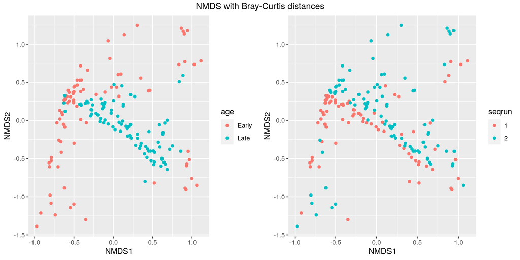

```r
p1 <- plot_ordination(ps, ord.nmds.bray, color='age')
p2 <- plot_ordination(ps, ord.nmds.bray, color='seqrun')
grid.arrange(p1, p2, nrow=1, top='NMDS with Bray-Curtis distances')
```

The stress value is 0.1559093. Values below 0.2 are just fine. Below 0.15 would be much better. In any case, the main conclusion I draw from this plot is that the main difference between early and late microbiomes is that early ones are more dispersed.

I have tried to produce an NMDS using Sørensen's distance, which is the Bray-Curtis equivalent for presence-absence data (Tamás, Podani, and Csontos 2001). Unfortunately, the NMDS algorithm fails to converge in any acceptable solution when using Sørensen's distance.

## Principal Coordinates Analysis (PCoA)

PCoA also uses a distance matrix as input data, rather than the raw abundance values. Its purpose is also to display a set of objects in a reduced dimensionality space while respecting as much as possible the original distances among them.

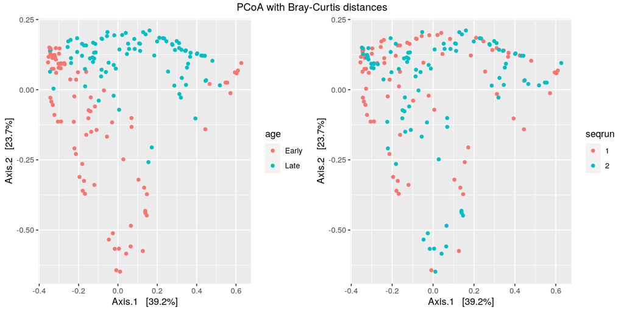

```r
ord.pcoa.bray <- ordinate(ps.pruned, method='PCoA', distance='bray', correction='cailliez')
p1 <- plot_ordination(ps.pruned, ord.pcoa.bray, color='age')
p2 <- plot_ordination(ps.pruned, ord.pcoa.bray, color='seqrun')
grid.arrange(p1, p2, nrow=1, top='PCoA with Bray-Curtis distances')
```

Maybe the main difference between PCoA and NMDS is that in PCoA plot, only the variation along two main axes is represented, while in NMDS all the variation is squeezed in the two dimensions.

In PCoA, we can use any distance, like Sørensen's, which lets us evaluate the effect of using binary (presence/absence) instead of quantitative data.

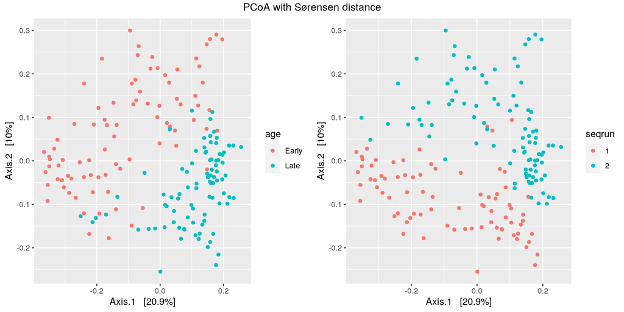

```r
# Note that using 'sor' as the distance, the resulting ordination is completely wrong,
# because the 'sor' distance (from betadiver) returns similarities, not dissimilarities.
# And apparently, phyloseq's ordinate does not take that into account. Distance 't' is
# the complement of Sørensen's index.
ord.pcoa.sor <- ordinate(ps.pruned, method='PCoA', distance='t', correction='cailliez')
p1 <- plot_ordination(ps.pruned, ord.pcoa.sor, color='age')
p2 <- plot_ordination(ps.pruned, ord.pcoa.sor, color='seqrun')
grid.arrange(p1, p2, nrow=1, top='PCoA with Sørensen distance')
```

Neither Bray-Curtis nor Sørensen distances are metric: they do not follow the triangle inequality axiom. Thus, they cannot be properly represented in a Euclidean space. Negative eigenvalues appear. Nevertheless, the results are both very reasonable. It is actually surprising that the binary Sørensen distance separate so well between early and late samples, and between first and second batches.

Apparently, one of the original motivations for the development of PCoA was to incorporate phylogenetic information in the distances among communities, something that principal component analysis (PCA) cannot do. It does sound like a very good idea. Let's see how the phylogeny contributes to the PCoA plot:

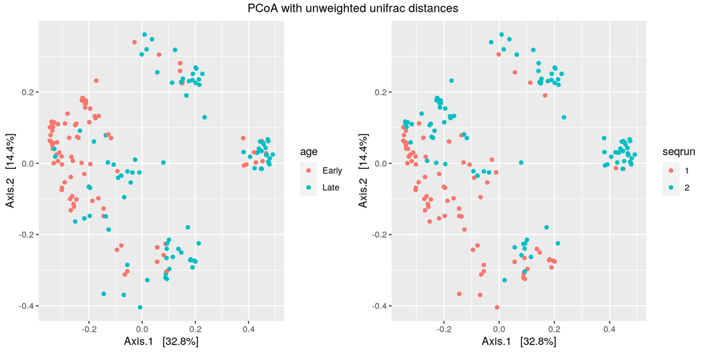

```r
ord.pcoa.unifrac  <- ordinate(ps.pruned, method='PCoA', distance='unifrac')
ord.pcoa.wunifrac <- ordinate(ps.pruned, method='PCoA', distance='wunifrac')
p1 <- plot_ordination(ps.pruned, ord.pcoa.unifrac, color='age')
p2 <- plot_ordination(ps.pruned, ord.pcoa.unifrac, color='seqrun')
p3 <- plot_ordination(ps.pruned, ord.pcoa.wunifrac, color='age')
p4 <- plot_ordination(ps.pruned, ord.pcoa.wunifrac, color='seqrun')
grid.arrange(p1, p2, nrow=1, top='PCoA with unweighted unifrac distances')
```

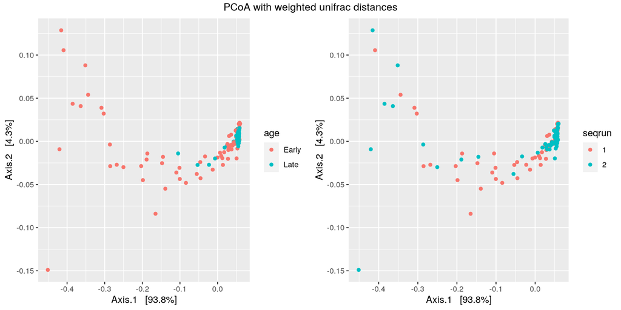

```r
grid.arrange(p3, p4, nrow=1, top='PCoA with weighted unifrac distances')
```

For some reason, the *wunifrac* distance gives unstable results. In any case, the point is that both phylogenetic distances among amplicons and abundances have a strong influence in the overall ordination of samples. But up to now, the most clear distinction between early and late-life samples was achived with a binary distance.

## The role of double absences

Ecologists avoid distance measures in which common absences contribute to similarity. This is called 'the double zero problem' (P. Legendre and Legendre 2012, 253):

> The double-zero problem shows up in ecology because of the special nature of species descriptors. Species are known to have unimodal distributions along environmental gradients (Whittaker, 1967). Hutchinson’s (1957) niche theory states that species have ecological preferences, meaning that they are more likely to be found at sites where they encounter appropriate living conditions; the distribution of a species has its mode at this optimum value. A species becomes rare and eventually absent as one departs from optimal conditions. If a species is present at two sites, this is an indication of the similarity of these sites; but if a species is absent from two sites, it may be because the two sites are both above the optimal niche value for that species, or both are below, or else one site is above and the other is below that value. One cannot tell which of these circumstances is the correct one.

> It is thus preferable to abstain from drawing any ecological conclusion from the absence of a species at two sites. In numerical terms, this means to skip double zeros altogether when computing similarity or distance coefficients using species presence- absence or abundance data. Coefficients of this type are called asymmetrical because they treat zeros in a different way than other values.

For gut microbial communities of a single host species in laboratory conditions, it is hard to believe that we are sampling beyond the optimal environment of any microbial species. In the current setting, we probably should not expect taxa to show a unimodal distribution. Even across isolines, there is no *a priori* reason to think that some isolines offer a better environment to particular bacteria than others.

In any case, the focus of the experimental design are not the causes but the consequences of variation in gut microbiome composition. What is considered similar or different depends on whether the variable is explanatory or a response. Because an absence can be caused by several unknown factors (e.g., either too low or too high salinity), it should not count as a similarity. But when assessing the consequences of an absence, any two absences are causaly equivalent, and they should count in the similarity measure.

(Faith 1983) suggested a binary similarity measure that considers double absences as neutral, contributing neither to similarity nor to distance. It is defined as $C=\frac{a + 0.5d}{N}$, where $a$ is the number of species present in both sites, $d$ the number of double absences, and $N$, the total number of species. If double absences were to count just as much as a mismatch to distance, $C$ would turn into Russell and Rao similarity: $\frac{a}{N}$. On the other side, if double absences were to contribute to similarity as much as double presences, then $C$ would turn into the Raw similarity, $\frac{a+d}{N}$. They can all be easily implemented with the function `designdist()`. Corresponding distances are obtained subtracting similarities from 1.

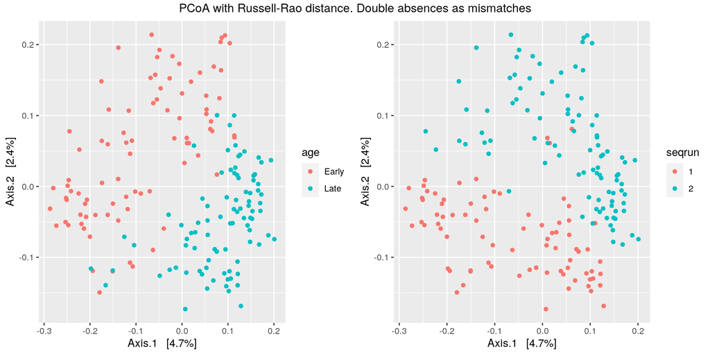

```r
ord.pcoa.RussellRao <- pcoa(designdist(otu_table(ps.pruned),
                                       method = '1 - a / (a + b + c + d)',
                                       abcd = TRUE),
                            rn = sample_names(ps.pruned), correction = 'lingoes')
ord.pcoa.faith      <- pcoa(designdist(otu_table(ps.pruned),
                                       method = '1 - (a + 0.5 * d) / (a + b + c + d)',
                                       abcd = TRUE),
                            rn = sample_names(ps.pruned), correction = 'lingoes')
ord.pcoa.raw        <- pcoa(designdist(otu_table(ps.pruned),
                                       method = '1 - (a + d) / (a + b + c + d)',
                                       abcd = TRUE),
                            rn = sample_names(ps.pruned), correction = 'lingoes')
p1 <- plot_ordination(ps.pruned, ord.pcoa.RussellRao, color='age')
p2 <- plot_ordination(ps.pruned, ord.pcoa.RussellRao, color='seqrun')
p3 <- plot_ordination(ps.pruned, ord.pcoa.faith, color='age')
p4 <- plot_ordination(ps.pruned, ord.pcoa.faith, color='seqrun')
p5 <- plot_ordination(ps.pruned, ord.pcoa.raw, color='age')
p6 <- plot_ordination(ps.pruned, ord.pcoa.raw, color='seqrun')
grid.arrange(p1, p2, nrow=1, top='PCoA with Russell-Rao distance. Double absences as mismatches')
```

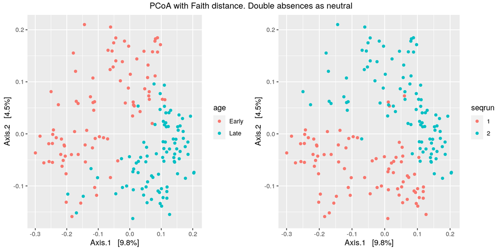

```r
grid.arrange(p3, p4, nrow=1, top='PCoA with Faith distance. Double absences as neutral')
```

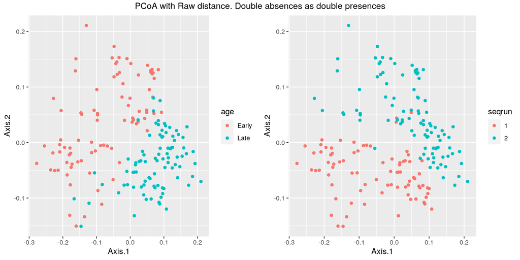

```r
grid.arrange(p5, p6, nrow=1, top='PCoA with Raw distance. Double absences as double presences')
```

The Raw distances produced some negative eigenvalues and triggered the correction. That may be the reason why the relative eigenvalues of the axes are not specified in the last plot. With Raw distances, the relative eigenvalue of axis 1 is 0.12 %, and that for axis 2 is 0.05 %.

Tamás, Podani, and Csontos (2001) generalize several distance measures that take absences into account from the binary to the quantitative scale. Their genaralization of the binary distance defined by D.P. Faith in 1983, called *C* above, can help us reveal the effect of doble absences in our data set. The index is a similarity and is given by equation 9b in Tamás, Podani, and Csontos (2001):

$FA2q_{jk} = \frac{\sum_{i=1}^n min(x_{ij}, x_{ik}) + 0.5\sum_{i=1}^n (\max_j(x_{ij}) - \max(x_{ij},x_{ik}))}{\sum_{i=1}^n\max_j(x_{ij})}$

Unfortunately, the `designdist()` function does not allow a direct implementation of this similarity index. I use my own implementation below. I make the 0.5 factor variable to obtain quantitative analogs of Raw and Russell and Rao distances.

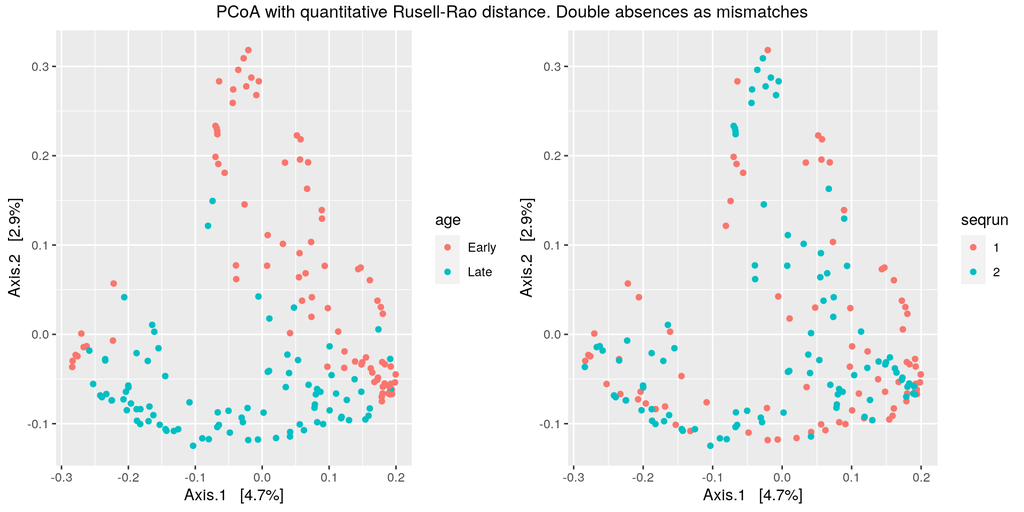

```r
Faith2q <- function(x, W=0.5){
  maxj <- apply(x, 2, max)  # vector of maximum abundances species achieve across sites.
  d <- matrix(0, nrow=nrow(x), ncol=nrow(x))  # comparing rows, assumed to be 'sites'
  for (j in 2:nrow(x)) {
    for (i in 1:(j-1)) {
      d[j,i] <- 1 -
        (sum(pmin.int(x[i,], x[j,])) + W * sum(maxj - pmax.int(x[i,], x[j,]))) / sum(maxj)
    }
  }
  return(as.dist(d))
}
ord.pcoa.faith2qW0 <- pcoa(Faith2q(otu_table(ps.pruned), W=0),
                         rn=sample_names(ps.pruned), correction='lingoes')
ord.pcoa.faith2qW05 <- pcoa(Faith2q(otu_table(ps.pruned), W=0.5),
                            rn=sample_names(ps.pruned), correction='lingoes')
ord.pcoa.faith2qW1 <- pcoa(Faith2q(otu_table(ps.pruned), W=1),
                           rn=sample_names(ps.pruned), correction='lingoes')
p1 <- plot_ordination(ps.pruned, ord.pcoa.faith2qW0, color='age')
p2 <- plot_ordination(ps.pruned, ord.pcoa.faith2qW0, color='seqrun')
p3 <- plot_ordination(ps.pruned, ord.pcoa.faith2qW05, color='age')
p4 <- plot_ordination(ps.pruned, ord.pcoa.faith2qW05, color='seqrun')
p5 <- plot_ordination(ps.pruned, ord.pcoa.faith2qW1, color='age')
p6 <- plot_ordination(ps.pruned, ord.pcoa.faith2qW1, color='seqrun')
grid.arrange(p1, p2, nrow=1, top='PCoA with quantitative Rusell-Rao distance. Double absences as mismatches')
```

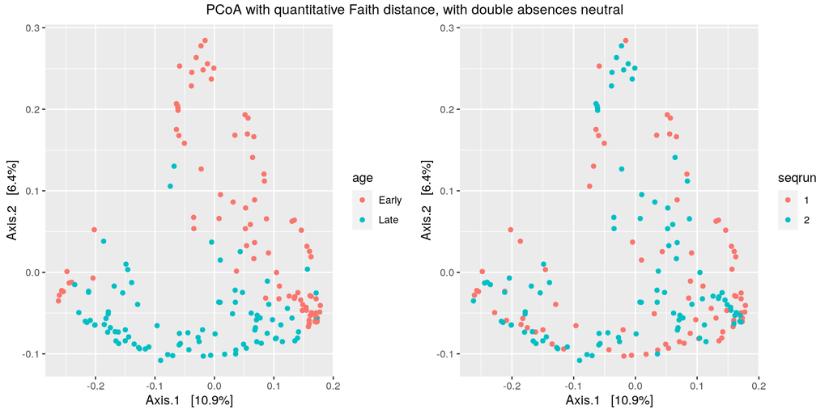

```r
grid.arrange(p3, p4, nrow=1, top='PCoA with quantitative Faith distance, with double absences neutral')
```

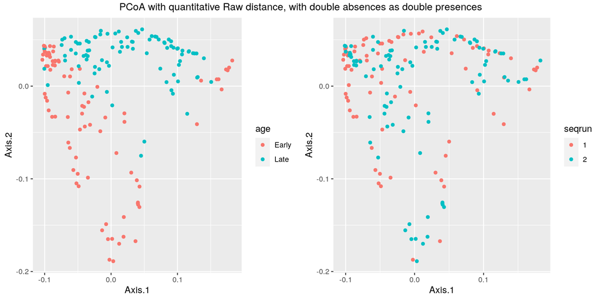

```r
grid.arrange(p5, p6, nrow=1, top='PCoA with quantitative Raw distance, with double absences as double presences')
```

Axes in the last plot, for quantitative version of Raw distance, have 0.08 and 0.05 % relative eigenvalues.

# Redundancy analysis

Ordination analyses are a set of multivariate methods that can be classified in three main groups, according to their main purpose: exploratory, interpretative and discriminatory methods (Paliy and Shankar 2016).

In our model, microbiome composition is but a predictor variable of life-history variables related to fitness and measured on isolines. To be more precise, for every isoline we have measured two microbiome compositions (with replicates): one early and one late in life. They are expected to be correlated, but different, and both may contribute to explain life-history traits. The main question is to what extent microbiome composition influences life-history traits, and how. This is not an exploratory analysis, but an interpretative one, in which we use a large set of variables (taxa abundances) to try to explain part of the variation in life-history traits.

A redundancy analysis (RDA in the literature) seems to be the best choice, although multivariate versions of generalized linear models (GLM) are also a possibility (Paliy and Shankar 2016). The `vegan` package includes an `rda()` function, that takes community data as the presumed response variables, and expects environmental data as the explanatory ones. That's the typical usage in ecology, and also microbial ecology (C. Zhang et al. 2012, e.g.). But our goal is the reverse: to explain isoline (community-level) properties by their microbiome composition.

## Standardization of response variables

P. Legendre and Legendre (2012) recommends to standardize the response variables to make interpretation easier. I create a new data frame `Y` with the standardized variables, using only values for the isolines for which we also have microbiome data.

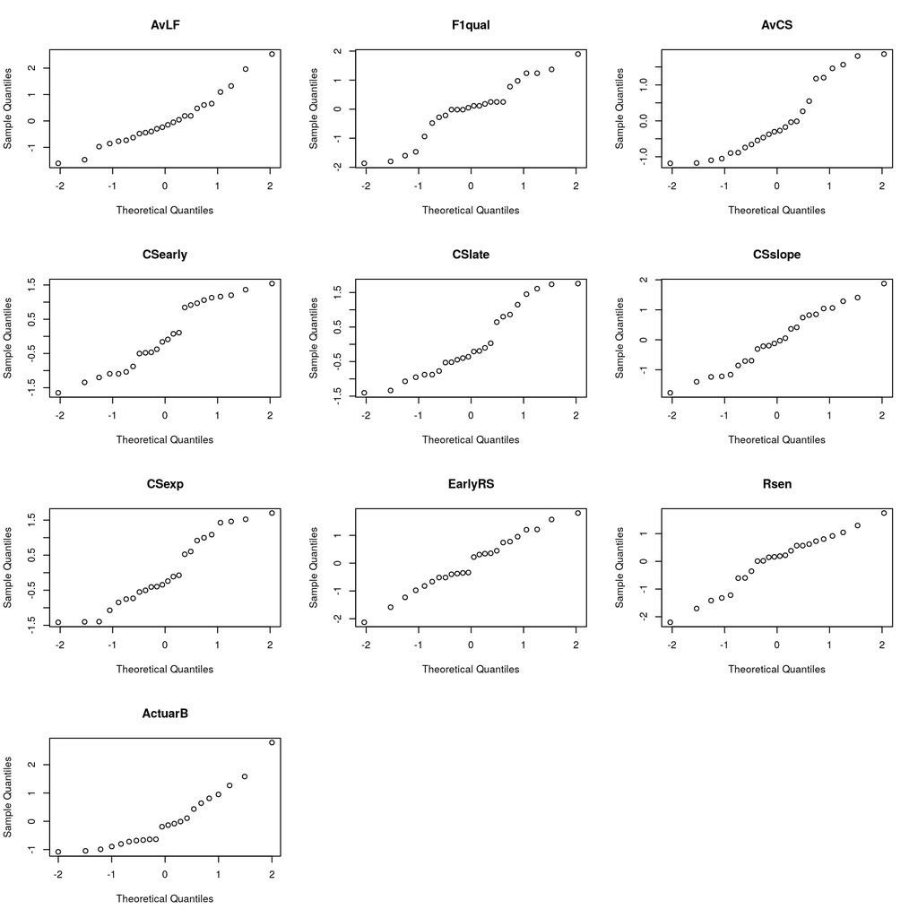

```r
validIsolines <- as.numeric(levels(sample_data(ps.pruned)$isoline))
LH <- LH[match(validIsolines, LH$Isoline),]
Y <- data.frame(isoline = LH$Isoline)
Y$AvLF    <- (LH$AvLF       - mean(LH$AvLF,       na.rm=TRUE)) / sd(LH$AvLF,       na.rm=TRUE)
Y$F1qual  <- (LH$F1quality  - mean(LH$F1quality,  na.rm=TRUE)) / sd(LH$F1quality,  na.rm=TRUE)
Y$AvCS    <- (LH$AvCS       - mean(LH$AvCS,       na.rm=TRUE)) / sd(LH$AvCS,       na.rm=TRUE)
Y$CSearly <- (LH$CSearly    - mean(LH$CSearly,    na.rm=TRUE)) / sd(LH$CSearly,    na.rm=TRUE)
Y$CSlate  <- (LH$CSlate     - mean(LH$CSlate,     na.rm=TRUE)) / sd(LH$CSlate,     na.rm=TRUE)
Y$CSslope <- (LH$CSSlope    - mean(LH$CSSlope,    na.rm=TRUE)) / sd(LH$CSSlope,    na.rm=TRUE)
Y$CSexp   <- (LH$CSexp      - mean(LH$CSexp,      na.rm=TRUE)) / sd(LH$CSexp,      na.rm=TRUE)
Y$EarlyRS <- (LH$EarlyRS    - mean(LH$EarlyRS,    na.rm=TRUE)) / sd(LH$EarlyRS,    na.rm=TRUE)
Y$Rsen    <- (LH$Rsen       - mean(LH$Rsen,       na.rm=TRUE)) / sd(LH$Rsen,       na.rm=TRUE)
Y$ActuarB <- (LH$ActuarialB - mean(LH$ActuarialB, na.rm=TRUE)) / sd(LH$ActuarialB, na.rm=TRUE)
par(mfrow=c(4,3))
  qqnorm(Y$AvLF,    main = 'AvLF')
  qqnorm(Y$F1qual,  main = 'F1qual')
  qqnorm(Y$AvCS,    main = 'AvCS')
  qqnorm(Y$CSearly, main = 'CSearly')
  qqnorm(Y$CSlate,  main = 'CSlate')
  qqnorm(Y$CSslope, main = 'CSslope')
  qqnorm(Y$CSexp,   main = 'CSexp')
  qqnorm(Y$EarlyRS, main = 'EarlyRS')
  qqnorm(Y$Rsen,    main = 'Rsen')
  qqnorm(Y$ActuarB, main = 'ActuarB')
par(mfrow=c(1,1))
```

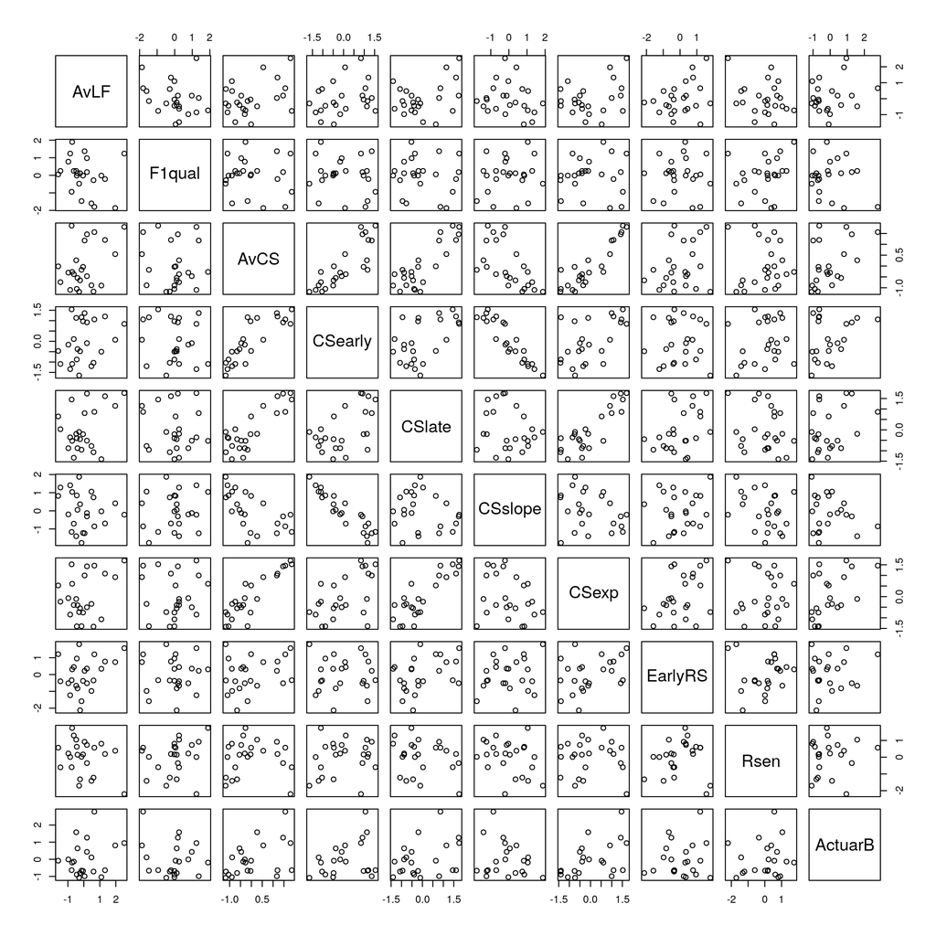

```r
pairs(Y[,-1])
```

## Definition of the 'objects'

Clearly, the isolines are the 'objects' the properties of which we want to explain. But we have taxa abundance data for several replicates of each isoline in early and late time points. I was reluctant to combine abundance data among replicates, because it will collapse the biological variation among replicates. That's something we would not do, for example, to compare abundances among time points or among isolines (see `2020-03-17`). And it will probably bias our results here as well, because reducing 3 or 4 abundance data points to only one makes it look just as precise as any other, while in reality some abundances are much more variable than others. I don't see a way around it. The possibility of duplicating the rows of the `Y` matrix to match the replicates would not work. Even if that didn't affect the redundancy analysis (I don't know), it would still create a problem with the two time points. Abundance of a taxon early in life is a different variable from the abundance of the same taxon late in life, because their effects on the response variables might be different. That means I need to split the abundance matrix by the `age` factor, and then combine the two pieces by column, side to side. I cannot do that before collapsing the replicates, because not all isolines have the same number of replicates in the two time points. And even if they did, it would be wrong to match replicates from early with replicates from late in life.

## Preparation of the explanatory variables

I need to start over again from the original table of abundances, after the removal of chimeras and a light filtering in `2020-02-11`. Abundances and taxonomy information are stored at this stage in two matrices, `SeqTabNoChim` (with dimensions 177, 2675) and `taxa` (2683, 7). Column names in `SeqTabNoChim` are the amplicon sequences. Row names are fastq file names.

```r
# Renaming the amplicons
dna <- DNAStringSet(row.names(taxa))
names(dna) <- sprintf("A%04i", seq(dim(taxa)[1])) # Naming all available sequences, even filtered
row.names(taxa)        <- names(dna)[match(row.names(taxa), dna)]
colnames(SeqTabNoChim) <- names(dna)[match(colnames(SeqTabNoChim), dna)]
SampleData <- data.frame(
  age = factor(substr(row.names(SeqTabNoChim), 1, 1), levels=c('E','L'), labels=c('Early','Late')),
  isoline = factor(stringr::str_extract(rownames(SeqTabNoChim), "[[:digit:]]+"),
                   levels=as.character(c(6,10,11,12,14,15,17,19,20,22,23,24,25,26,27,28,29,30,31,33,35,36,38,39)),
                   ordered=FALSE),
  replicate = gsub("([EL][[:digit:]]+|.fastq.gz)", "", rownames(SeqTabNoChim)),
  seqrun = factor(1, levels=c(1,2))
)
run2 <- row.names(SeqTabNoChim) %in% c('E22C.fastq.gz', 'E23A.fastq.gz', 'E25A.fastq.gz',
                                       'E25B.fastq.gz', 'E25C.fastq.gz', 'E25D.fastq.gz',
                                       'E26A.fastq.gz', 'E26B.fastq.gz', 'E26C.fastq.gz',
                                       'E26D.fastq.gz', 'E27A.fastq.gz', 'E27B.fastq.gz',
                                       'E27C.fastq.gz', 'E28A.fastq.gz', 'E28B.fastq.gz',
                                       'E28C.fastq.gz', 'E28D.fastq.gz', 'E29A.fastq.gz',
                                       'E29B.fastq.gz', 'E29C.fastq.gz', 'E29D.fastq.gz',
                                       'E30A.fastq.gz', 'E30B.fastq.gz', 'E30C.fastq.gz',
                                       'E30D.fastq.gz', 'E31A.fastq.gz', 'E31B.fastq.gz',
                                       'E31C.fastq.gz', 'E31D.fastq.gz', 'E33A.fastq.gz',
                                       'E33B.fastq.gz', 'E33C.fastq.gz', 'E33D.fastq.gz',
                                       'E35A.fastq.gz', 'E35B.fastq.gz', 'E35C.fastq.gz',
                                       'E35D.fastq.gz', 'E36A.fastq.gz', 'E36B.fastq.gz',
                                       'E36C.fastq.gz', 'E36D.fastq.gz', 'E38A.fastq.gz',
                                       'E38B.fastq.gz', 'E38C.fastq.gz', 'E38D.fastq.gz',
                                       'E39A.fastq.gz', 'E39B.fastq.gz', 'E39C.fastq.gz',
                                       'E39D.fastq.gz', 'L23B.fastq.gz', 'L24C.fastq.gz',
                                       'L25A.fastq.gz', 'L25B.fastq.gz', 'L25C.fastq.gz',
                                       'L25D.fastq.gz', 'L26A.fastq.gz', 'L26B.fastq.gz',
                                       'L26C.fastq.gz', 'L26D.fastq.gz', 'L27A.fastq.gz',
                                       'L27B.fastq.gz', 'L27C.fastq.gz', 'L28A.fastq.gz',
                                       'L28B.fastq.gz', 'L28C.fastq.gz', 'L28D.fastq.gz',
                                       'L29A.fastq.gz', 'L29B.fastq.gz', 'L29C.fastq.gz',
                                       'L29D.fastq.gz', 'L30A.fastq.gz', 'L30B.fastq.gz',
                                       'L30C.fastq.gz', 'L30D.fastq.gz', 'L31A.fastq.gz',
                                       'L31B.fastq.gz', 'L31C.fastq.gz', 'L31D.fastq.gz',
                                       'L33A.fastq.gz', 'L33B.fastq.gz', 'L33C.fastq.gz',
                                       'L33D.fastq.gz', 'L35B.fastq.gz', 'L35C.fastq.gz',
                                       'L35D.fastq.gz', 'L36A.fastq.gz', 'L36B.fastq.gz',
                                       'L36C.fastq.gz', 'L36D.fastq.gz', 'L38A.fastq.gz',
                                       'L38B.fastq.gz', 'L38C.fastq.gz', 'L38D.fastq.gz',
                                       'L39A.fastq.gz', 'L39B.fastq.gz', 'L39C.fastq.gz',
                                       'L39D.fastq.gz')
SampleData$seqrun[run2] <- 2
row.names(SampleData) <- row.names(SeqTabNoChim)

isEarly <- SampleData$age == 'Early'
isLate  <- SampleData$age == 'Late'
EarlyAbundance <- SeqTabNoChim[isEarly,]
LateAbundance  <- SeqTabNoChim[isLate,]
EarlyIsoline <- SampleData[isEarly, 'isoline']
LateIsoline  <- SampleData[isLate,  'isoline']
# I found it impossible to do the following with plyr:
EA <- do.call(rbind, lapply(split(as.data.frame(EarlyAbundance), EarlyIsoline), colSums))
LA <- do.call(rbind, lapply(split(as.data.frame(LateAbundance),  LateIsoline),  colSums))
dim(EA)
```

```
## [1]   24 2675
```

```r
dim(LA)
```

```
## [1]   24 2675
```

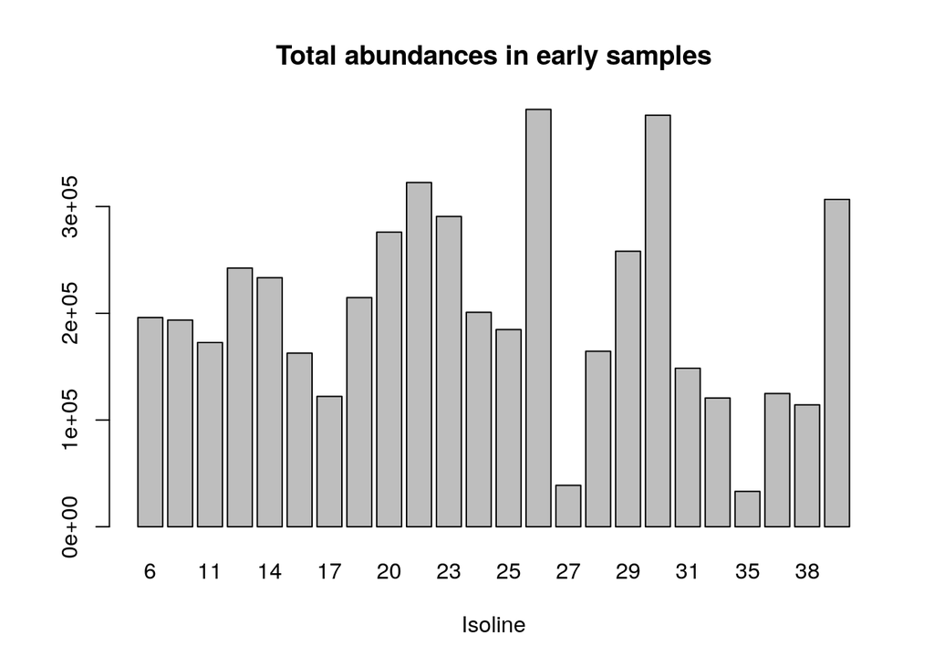

```r
barplot(rowSums(EA), xlab='Isoline', main='Total abundances in early samples')
```

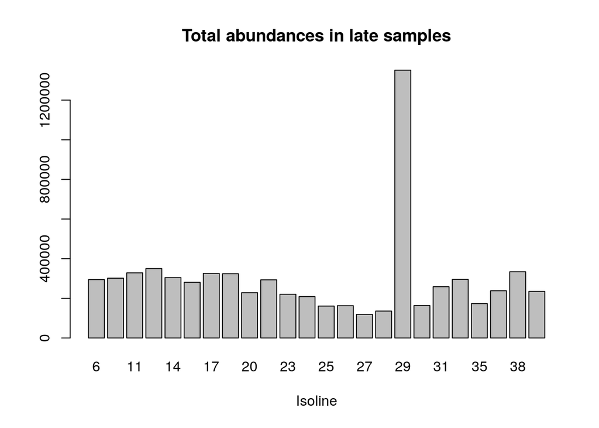

```r
barplot(rowSums(LA), xlab='Isoline', main='Total abundances in late samples')
```

Isolines 27 and 35 have very low counts among the early samples. If I keep them, I should only use the taxa that are abundant enough to have at least a chance of being counted in isolines 27 and 35. I will keep them for the moment, because I don't know if using thousands of explanatory variables is feasible, anyways. Plus, the more low-abundance taxa we remove, the easier should the normalization be.

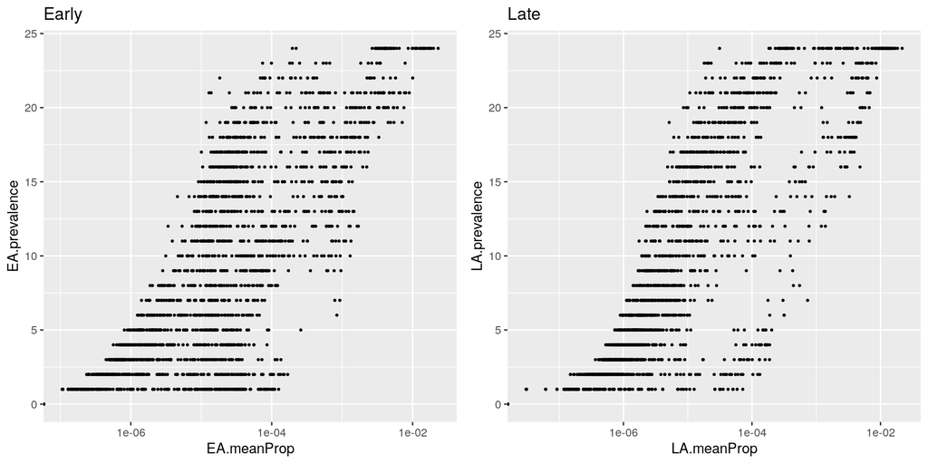

```r
# It would not make sense to estimate proportions after filtering.
# I transpose to keep amplicons in columns and isolines in rows
EA.prop <- t(apply(EA, 1, function(x) x / sum(x)))
LA.prop <- t(apply(LA, 1, function(x) x / sum(x)))

AbundanceSummary <- data.frame(
  EA.meanProp = apply(EA.prop, 2, mean),
  LA.meanProp = apply(LA.prop, 2, mean),
  EA.prevalence = colSums(EA > 0),
  LA.prevalence = colSums(LA > 0)
)
p1 <- ggplot(AbundanceSummary, aes(x=EA.meanProp, y=EA.prevalence)) +
  geom_point(size=0.5) + scale_x_log10() + ggtitle('Early')
p2 <- ggplot(AbundanceSummary, aes(x=LA.meanProp, y=LA.prevalence)) +
  geom_point(size=0.5) + scale_x_log10() + ggtitle('Late')
grid.arrange(p1, p2, nrow=1)
```

```r
EA.filter <- AbundanceSummary$EA.meanProp >= 5.0e-5 & AbundanceSummary$EA.prevalence >= 5
LA.filter <- AbundanceSummary$LA.meanProp >= 5.0e-5 & AbundanceSummary$LA.prevalence >= 5

EA.prop.clean <- EA.prop[,EA.filter]
LA.prop.clean <- LA.prop[,LA.filter]
```

```r
EA.cat <- EA.prop.clean
EA.cat[EA.prop.clean <= 3.5e-6] <- 0
EA.cat[EA.prop.clean >  3.5e-6 & EA.prop.clean <= 2.0e-4] <- 1
EA.cat[EA.prop.clean >  2.0e-4 & EA.prop.clean <= 1.5e-3] <- 2
EA.cat[EA.prop.clean >  1.5e-3] <- 3
colnames(EA.cat) <- paste0('E', colnames(EA.cat))

LA.cat <- LA.prop.clean
LA.cat[LA.prop.clean <= 3.5e-6] <- 0
LA.cat[LA.prop.clean >  3.5e-6 & LA.prop.clean <= 2.0e-4] <- 1
LA.cat[LA.prop.clean >  2.0e-4 & LA.prop.clean <= 1.5e-3] <- 2
LA.cat[LA.prop.clean >  1.5e-3] <- 3
colnames(LA.cat) <- paste0('L', colnames(LA.cat))

Xcat <- cbind(EA.cat, LA.cat)

# This is (meant to be) the chi-square metric transformation in Legendre & Gallagher
# (2001; eq. 7).
EA.X2metric <- t(apply( EA, 1, function(x, A=colSums(EA)) x / (sum(x) * sqrt(A)) ))
LA.X2metric <- t(apply( LA, 1, function(x, A=colSums(LA)) x / (sum(x) * sqrt(A)) ))

# I filter after transformation, because I feel a transformation based on
# total abundances would not be what expected after filtering reduces total
# abundances.
EA.X2metric <- EA.X2metric[,EA.filter]
LA.X2metric <- LA.X2metric[,LA.filter]
colnames(EA.X2metric) <- paste0('E', colnames(EA.X2metric))
colnames(LA.X2metric) <- paste0('L', colnames(LA.X2metric))
X2metric <- cbind(EA.X2metric)
```

Below I run the RDA analysis. I exclude the first (*isoline*) and the last (*ActuarB*) variables in the response matrix. The reason to remove the *ActuarB* is that there are two missing values there. For the moment, I exclude that variable, to be able to report this preliminary analysis. I leave for the next report:

- Deal with the missing values in a more satisfactory way.
- Deal with the underdeterminatinon problem (too many explanatory variables).
- Evaluate the transformations.
- Remove the effect of the sequencing run.
- Interprete the results.

```r
RDA <- rda(X = Y[,-c(1,11)], Y = X2metric)
RDA
```

```
## Call: rda(X = Y[, -c(1, 11)], Y = X2metric)
##
##               Inertia Proportion Rank
## Total               9          1
## Constrained         9          1    8
## Unconstrained       0          0    0
## Inertia is variance
## Some constraints were aliased because they were collinear (redundant)
##
## Eigenvalues for constrained axes:
##  RDA1  RDA2  RDA3  RDA4  RDA5  RDA6  RDA7  RDA8
## 3.925 1.745 1.337 0.888 0.664 0.310 0.122 0.008
```

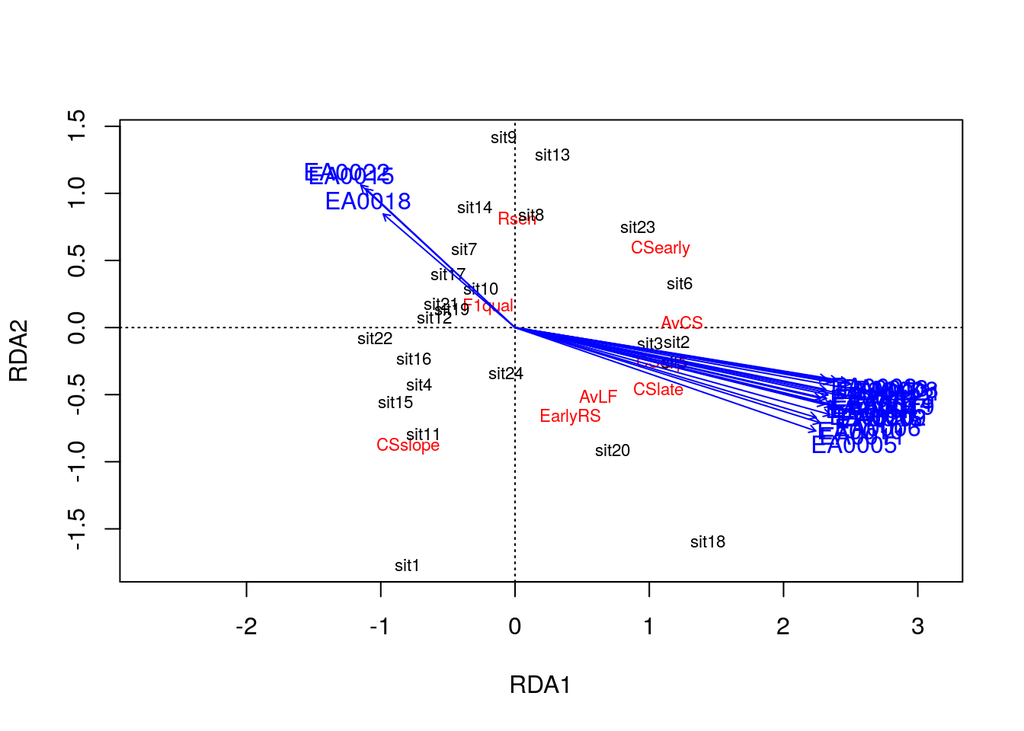

```r
plot(RDA)
```

# References

Faith, Daniel P. 1983. “Asymmetric Binary Similarity Measures.” *Oecologia* 57: 287–90. doi:10.1007/BF00377169.

Legendre, Pierre, and Louis Legendre. 2012. *Numerical Ecology*. Amsterdam: Elsevier.

Paliy, O., and V. Shankar. 2016. “Application of Multivariate Statistical Techniques in Microbial Ecology.” *Molecular Ecology* 25: 1032–57. doi:10.1111/mec.13536.

Pérez-Cobas, Ana Elena, Elisa Maiques, Alexandra Angelova, Purificación Carrasco, Andrés Moya, and Amparo Latorre. 2015. “Diet Shapes the Gut Microbiota of the Omnivorous Cockroach Blattella Germanica.” *FEMS Microbiology Ecology* 91 (4). doi:10.1093/femsec/fiv022.

Ricotta, C., and J. Podani. 2017. “On Some Properties of the Bray-Curtis Dissimilarity and Their Ecological Meaning.” *Ecological Complexity* 31: 201–2015. doi:10.1016/j.ecocom.2017.07.003.

Rosas, Tania, Carlos García-Ferris, Rebeca Domínguez-Santos, Pablo Llop, Amparo Latorre, and Andrés Moya. 2018. “Rifampicin Treatment of Blattella germanica Evidences a Fecal Transmission Route of Their Gut Microbiota.” *FEMS Microbiology Ecology* 94 (2): fiy002. doi:10.1093/femsec/fiy002.

Tamás, Júlia, János Podani, and Péter Csontos. 2001. “An Extension of Presence/Absence Coefficients to Abundance Data: A New Look at Absence.” *Journal of Vegetation Science* 12 (3): 401–10. doi:10.2307/3236854.

Zhang, Chenhong, Menghui Zhang, Xiaoyan Pang, Yufeng Zhao, Linghua Wang, and Liping Zhao. 2012. “Structural Resilience of the Gut Microbiota in Adult Mice Under High-Fat Dietary Perturbations.” *ISME J.*, no. 6: 1848–57. doi:10.1038/ismej.2012.27.